# Compare De-noised Data from COI Primers

Mary Fisher

2/9/2022

# Description

The first sequencing lane was designed to answer three questions:

1. Which primer(s) do we want to use for the remainder of the (1) Salish Sea Green crab, (2) Willapa Bay Green crab, and (3) Dungeness crab instars? Factors to consider: amplification of predator DNA, presence of expected prey / prey of particular interest
2. Are we getting usable data from the 2018 Salish Sea Green crab samples, which are subsamples of the 95% etOH in which dissected stomachs were stored?
3. Are there any major signals of contamination from the SEFS lab (not particularly relevant anymore)

# Set up

This script requires the following packages:

```r
library(here)
library(tidyverse)
library(magrittr)
library(cowplot)
```

User directories

```r
indir_blast  <- 'test-run-1/data/blast'
indir_asv    <- 'test-run-1/data/dada2_denoised'
indir_meta   <- 'test-run-1/data/dada2_denoised'
outdir       <- 'test-run-1/results'
```

What are the suffixes of the processed blast file with taxonomy from script 6?

```r
# hashes with unique staxids
suffix1 <- 'blast_uniqueIDs_taxonomy.csv'

# hashes with multiple IDs, that required the LCA function
suffix2 <- 'blast_multipleIDs_taxonomy.csv'
```

# Question 1: Primer Comparison

**Which primer(s) do we want to use for the remainder of the (1) Salish Sea Green crab, (2) Willapa Bay Green crab, and (3) Dungeness crab instars?**

## Data

To answer this question, we need both the ASV table and the Blast taxonomy.

```r
asv.b   <- readRDS(here(indir_asv,'BF3.Cleaning.before.Occ.model.rds'))
asv.b %<>% unnest(cols=c(Step2.tibble)) %>% dplyr::select(SampleID, Hash, nReads)
asv.l   <- readRDS(here(indir_asv,'Leray.Cleaning.before.Occ.model.rds'))
asv.l %<>% unnest(cols=c(Step2.tibble)) %>% dplyr::select(SampleID, Hash, nReads)
asv.lxt <- readRDS(here(indir_asv,'LerayXT.Cleaning.before.Occ.model.rds'))
asv.lxt %<>% unnest(cols=c(Step2.tibble)) %>% dplyr::select(SampleID, Hash, nReads)
```

Note that the processed blast taxonomy files have results from forward-only, reverse-only, and merged reads. for this comparison, let’s focus only on merged reads.

```r
tax_key.b <- read_csv(here(indir_blast, paste0("lane1_bf3_",suffix2))) %>%
  rename("Hash"=representative)
tax_key.b %<>%  bind_rows(read_csv(here(indir_blast, paste0("lane1_bf3_",suffix1))) %>%
              rename("Hash"=qseqid) %>%
                mutate(taxID="unique", score="unique") %>%
              dplyr::select(all_of(colnames(tax_key.b)))) %>%
  filter(dataset=="merged")

tax_key.l <- read_csv(here(indir_blast, paste0("lane1_leray_",suffix2))) %>%
  rename("Hash"=representative)
tax_key.l %<>%  bind_rows(read_csv(here(indir_blast, paste0("lane1_leray_",suffix1))) %>%
              rename("Hash"=qseqid) %>%
                mutate(taxID="unique", score="unique") %>%
              dplyr::select(all_of(colnames(tax_key.l)))) %>%
  filter(dataset=="merged")

tax_key.lxt <- read_csv(here(indir_blast, paste0("lane1_lerayxt_",suffix2))) %>%
  rename("Hash"=representative)
tax_key.lxt %<>%  bind_rows(read_csv(here(indir_blast, paste0("lane1_lerayxt_",suffix1))) %>%
              rename("Hash"=qseqid) %>%
                mutate(taxID="unique", score="unique") %>%
              dplyr::select(all_of(colnames(tax_key.lxt)))) %>%
  filter(dataset=="merged")
```

Connect the taxonomy to the hashes in the ASV tables.

```r
bdat   <- left_join(asv.b, tax_key.b,by="Hash")
ldat   <- left_join(asv.l, tax_key.l,by="Hash")
lxtdat <- left_join(asv.lxt, tax_key.lxt,by="Hash")
```

To differentiate between crab species and sampling groups, read in the sequencing metadata and connect to the `Sample_name` (actually just an ID number) in the ASV table.

```r
bdat <- left_join(bdat,read.csv(here("test-run-1","data","dada2_denoised","BF3_dada2_metadata.csv")),by="SampleID") %>%
  mutate(Locus="BF3")
ldat <- left_join(ldat,read.csv(here("test-run-1","data","dada2_denoised","Leray_dada2_metadata.csv")),by="SampleID") %>%
  mutate(Locus="Leray")
lxtdat <- left_join(lxtdat,read.csv(here("test-run-1","data","dada2_denoised","LerayXT_dada2_metadata.csv")),by="SampleID") %>%
  mutate(Locus="LerayXT")
```

```r
all_dat <- bind_rows(bdat,ldat,lxtdat)
```

## Missing Taxonomy

Which primers had the most reads that couldn’t be assigned taxonomy? **BF3**

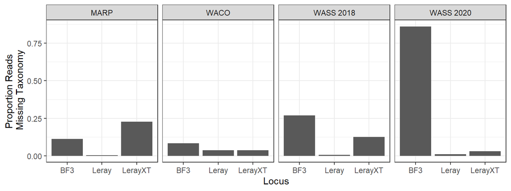

In contrast to the “noisy” data, LerayXT is missing taxonomy for a higher proportion of reads for the MARPT samples. BF3 is missing taxonomy for a higher proportion of reads in the WASS 2018/2020 denoised data than in the noisy data.

```r
all_dat2 <- filter(all_dat, !is.na(rank))
```

## Non-Target DNA

Which primers amplified the most bacterial / amoeba DNA? **BF3**

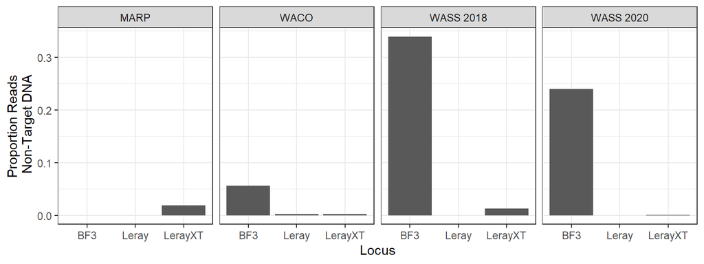

After denoising the data, there is a lot less bacterial DNA in the MARPT and WACO samples, because controls were subtracted from the samples. However, BF3 had a higher proportion of reads with non-target DNA in the denoised data than the noisy data for WASS 2018/2020.

```r
all_dat3 <- all_dat2 %>% filter(!(phylum %in% c(nontarget_taxa))) %>%
  filter(class!="Mammalia")
```

## Predator DNA

### EGC

Get only the Green Crab samples, and ignore hashes with missing taxonomic information.

```
## [1] WACO_2021_001  WACO_2021_002  WACO_2021_003  WASS_2018_062V WASS_2018_070V
## [6] WASS_2018_071V WASS_2020_190  WASS_2020_234  WASS_2020_334
## 14 Levels: Kangaroo MARPT_01 MARPT_02 PCRNegative ... WASS_2020_334
```

Which primer amplified the least Green Crab DNA? **LerayXT**

The most Green Crab DNA? **BF3** for WASS 2020 and WASS 2018, and **Leray** otherwise.

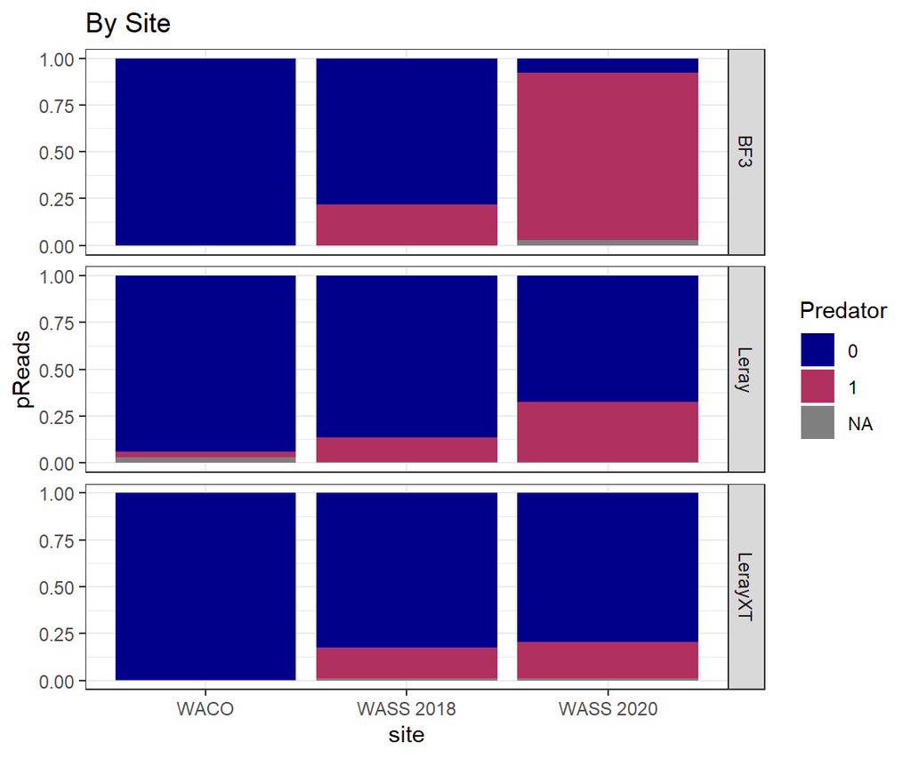

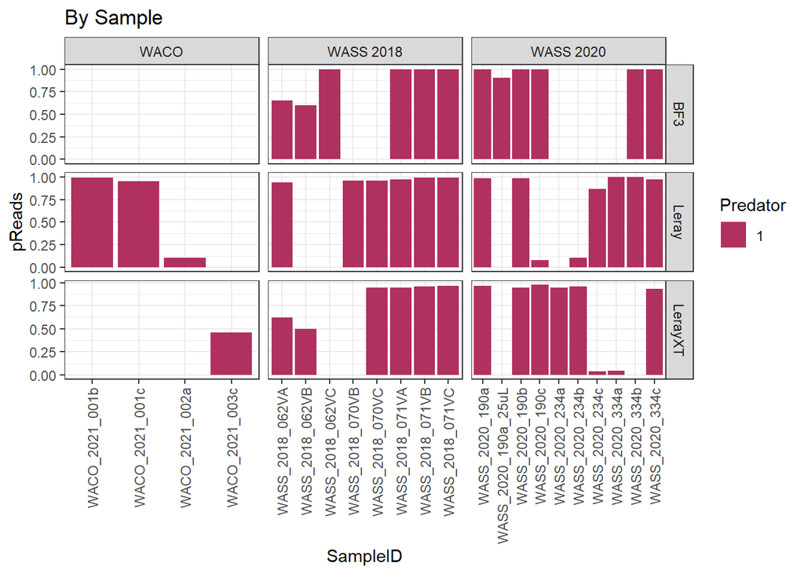

Subtracting out the controls reduced the amount of predator DNA left in the WACO samples (but also reduced the number of technical replicates with data); Just the BF3 WASS 2020 samples show about the same proprtion of predator DNA in the denoised data as in the noisy data.

```r
egc_dat2 <- filter(all_dat3, site %in% c("WACO","WASS 2018","WASS 2020")) %>%
  mutate(Predator=ifelse(taxon == "Carcinus maenas" | taxon == "Carcinus aestuarii" |
                           genus == "Carcinus",1,0)) %>%
  filter(Predator==0 | is.na(Predator))
```

### Dungies

Get only the Dungy samples, and ignore hashes with missing taxonomic information.

```
## [1] MARPT_01 MARPT_02
## 14 Levels: Kangaroo MARPT_01 MARPT_02 PCRNegative ... WASS_2020_334
```

Which primer amplified the least green crab DNA in the Dungy samples? **LerayXT**

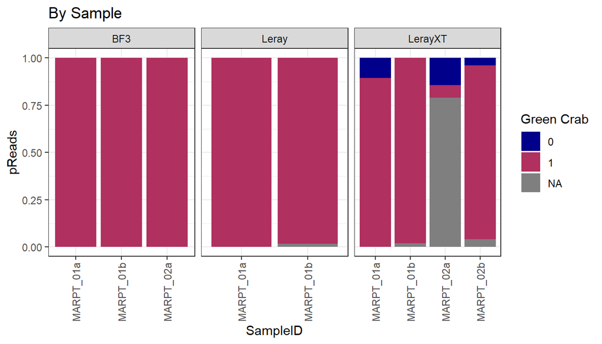

```r
dungy_dat2 <- dungy_dat %>%
  mutate(EGC=ifelse(taxon == "Carcinus maenas" | taxon == "Carcinus aestuarii" |
                           genus == "Carcinus",1,0)) %>%
  filter(EGC==0  | is.na(EGC))
```

## Prey Composition: diversity

### EGC

**How did diversity of phyla / taxa (family/genus/species) differ between primers?**

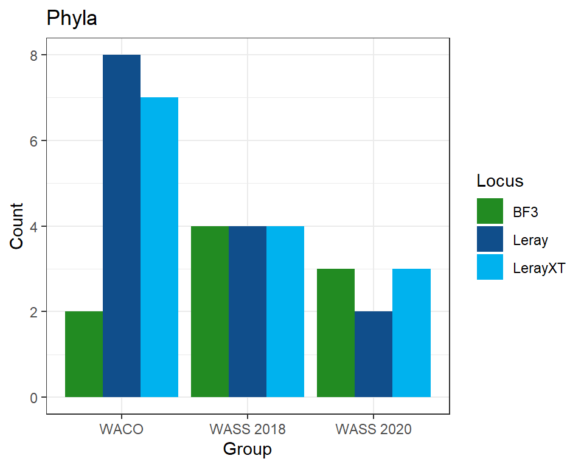

Unique phyla: Arthropoda, Mollusca, NA, Bacillariophyta, Cnidaria, Chlorophyta, Annelida, Rhodophyta, Ascomycota, Porifera, Tubulinea, Rotifera

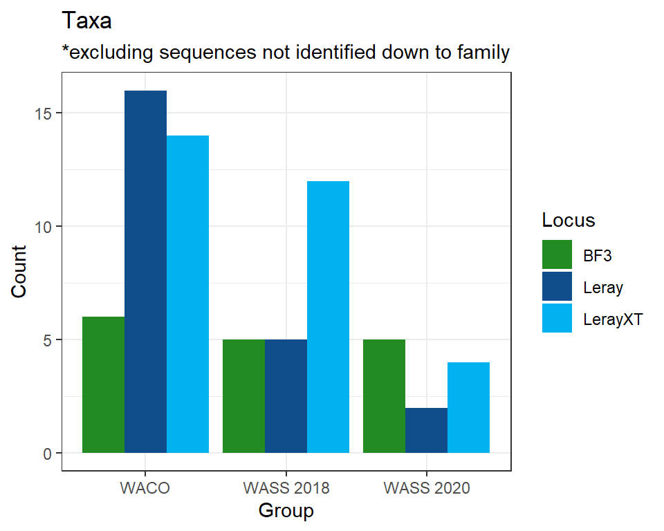

### Dungies

**How did diversity of phyla / taxa (family/genus/species) differ between primers?**

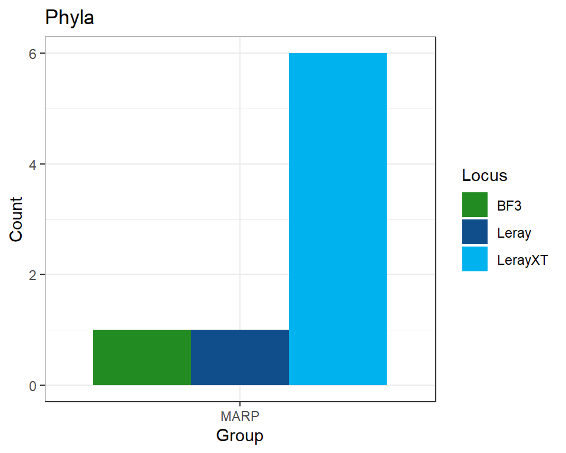

Unique phyla: NA, Arthropoda, Rotifera, Ascomycota, Rhodophyta, Annelida

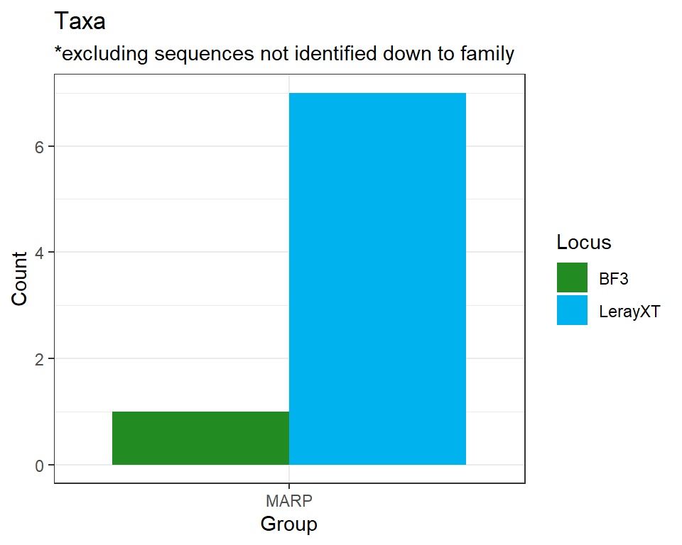

## Prey Composition: specificity

### EGC: Overview

**Which primer was able to detect the most ASVs down to the species level?**

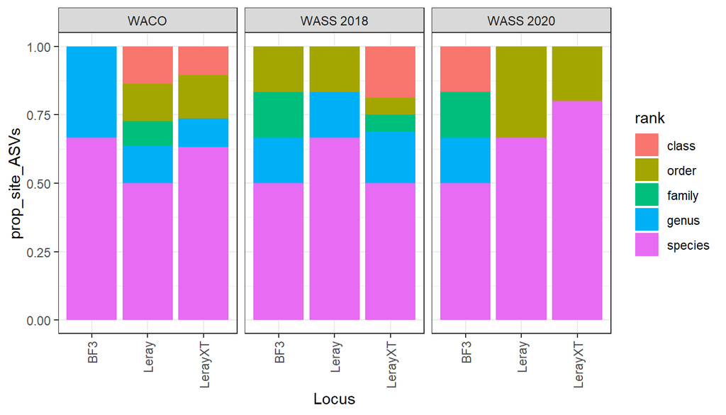

**For Arthropods, Molluscs, and Worms, which primer was able to detect the most ASVs down to the species level?** it varies by group and phylum. BF3 did best with molluscs and arthropods, but it didn’t pick up annelids and did worse than LerayXT in the WASS 2018 samples.

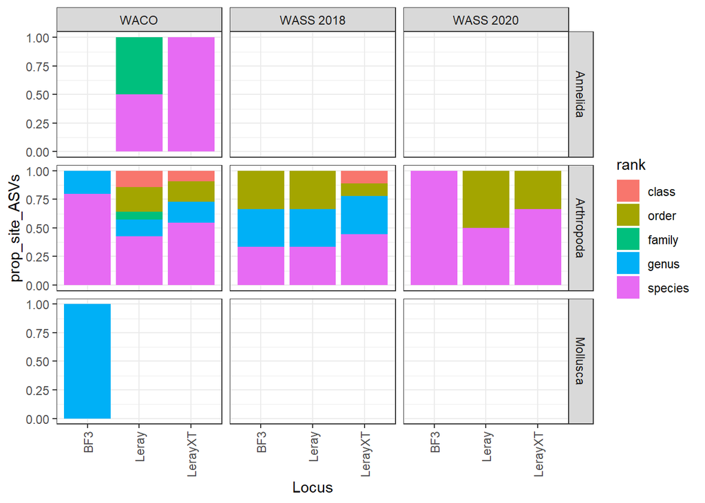

**What taxa (family/genus/species) were captured by only 1-2 primers?**

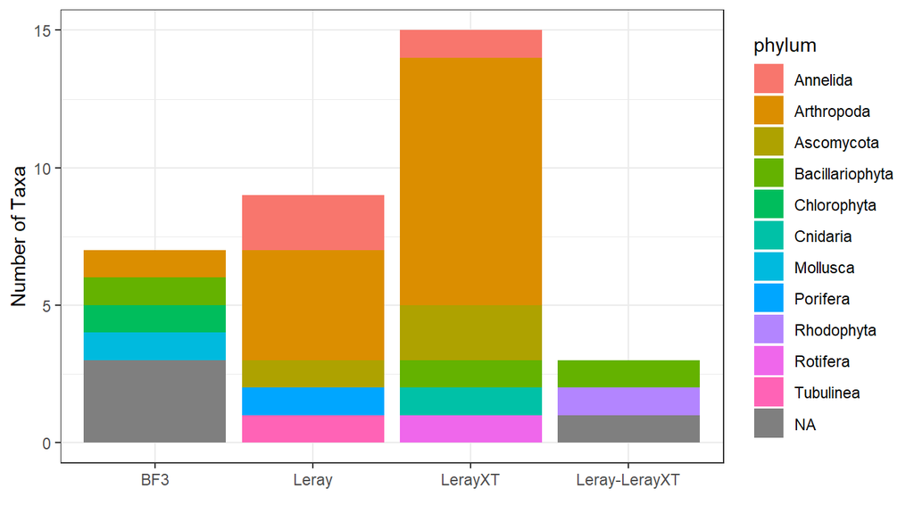

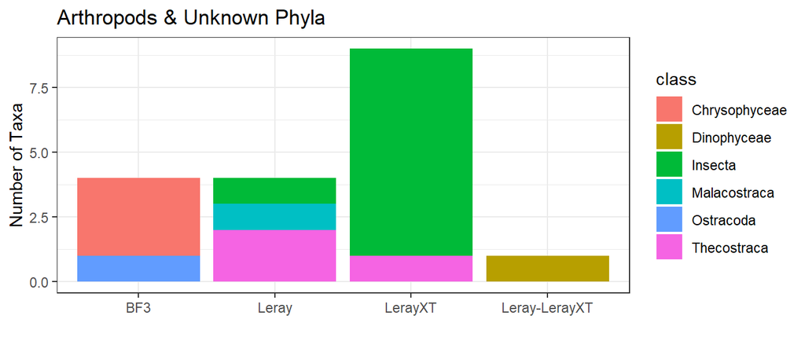

BF3 is picking up ostracods and a type of microscopic algae; Leray/LerayXT are picking up insects, barnacles (Leray down to species, LerayXT just *Balanus*); Leray is picking up some non-specific *malacostraca*… *Note - Dinophyceae >> Syndiniales >> Hematodinium are dinoflagellates that are internal parasites of crustaceans.*

### Dungy: Overview

**Which primer was able to detect the most ASVs down to the species level?**

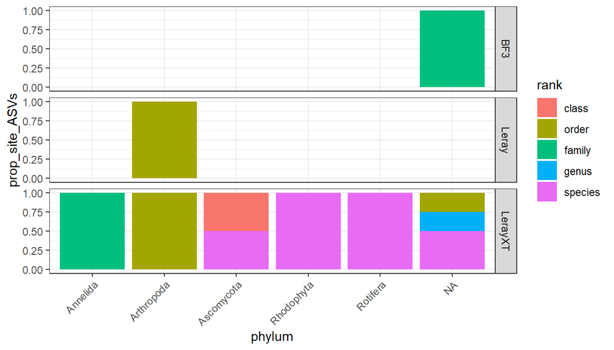

### EGC

Species of interest:

**1.** *Cancer (Metacarcinus) magister*

```
## # A tibble: 10 x 4
## # Groups:   SampleID, site [5]
##    site  SampleID       Locus   pReads
##    <fct> <chr>          <chr>    <dbl>
##  1 WACO  WACO_2021_001b BF3      0.979
##  2 WACO  WACO_2021_001b LerayXT  0.992
##  3 WACO  WACO_2021_001c BF3      0.962
##  4 WACO  WACO_2021_001c LerayXT  0.988
##  5 WACO  WACO_2021_002a Leray    0.229
##  6 WACO  WACO_2021_002a LerayXT  0.991
##  7 WACO  WACO_2021_002a BF3      1.00
##  8 WACO  WACO_2021_002b Leray    0.767
##  9 WACO  WACO_2021_002b LerayXT  0.989
## 10 WACO  WACO_2021_002c Leray    0.870
```

**2.** *Bivalvia*– most important is *Ruditapes philippinarium* (Manila clam)

```
## # A tibble: 1 x 6
## # Groups:   SampleID, site, Locus, taxon [1]
##   site  SampleID       Locus taxon rank    pReads
##   <fct> <chr>          <chr> <chr> <chr>    <dbl>
## 1 WACO  WACO_2021_001b BF3   Mya   genus 0.000216
```

# Question 2: WASS 2018 Vial Samples

**Are we getting usable data from the 2018 Salish Sea Green crab samples, which are subsamples of the 95% etOH in which dissected stomachs were stored?**

## Missing Taxonomy & Non-Target DNA

Do the 2018 samples have a higher proportion of any of the following, compared to the 2020/2021 samples?

1. missing taxonomy (**not consistently**),
2. non-target bacterial or amoeba DNA (**YES for BF3**)
3. predator DNA (**less than WASS 2020**)

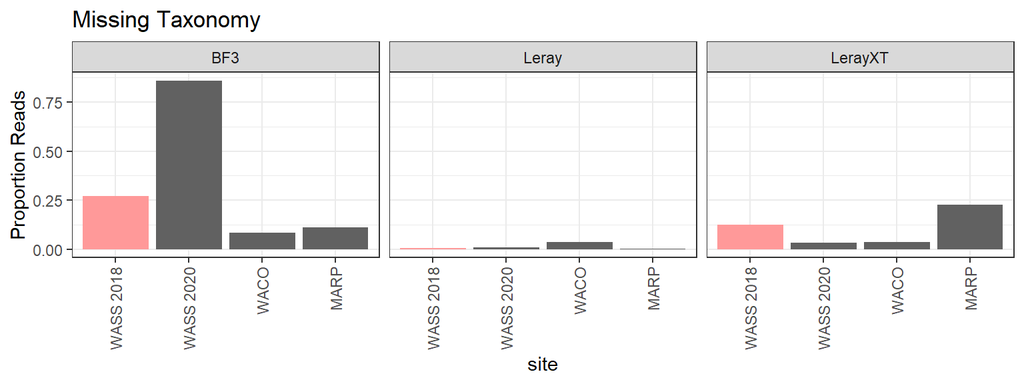

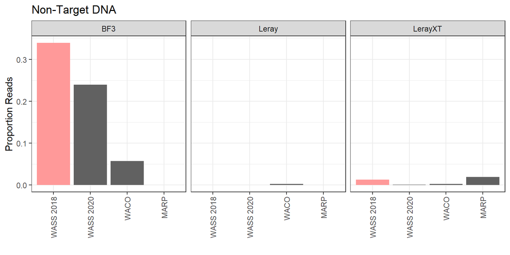

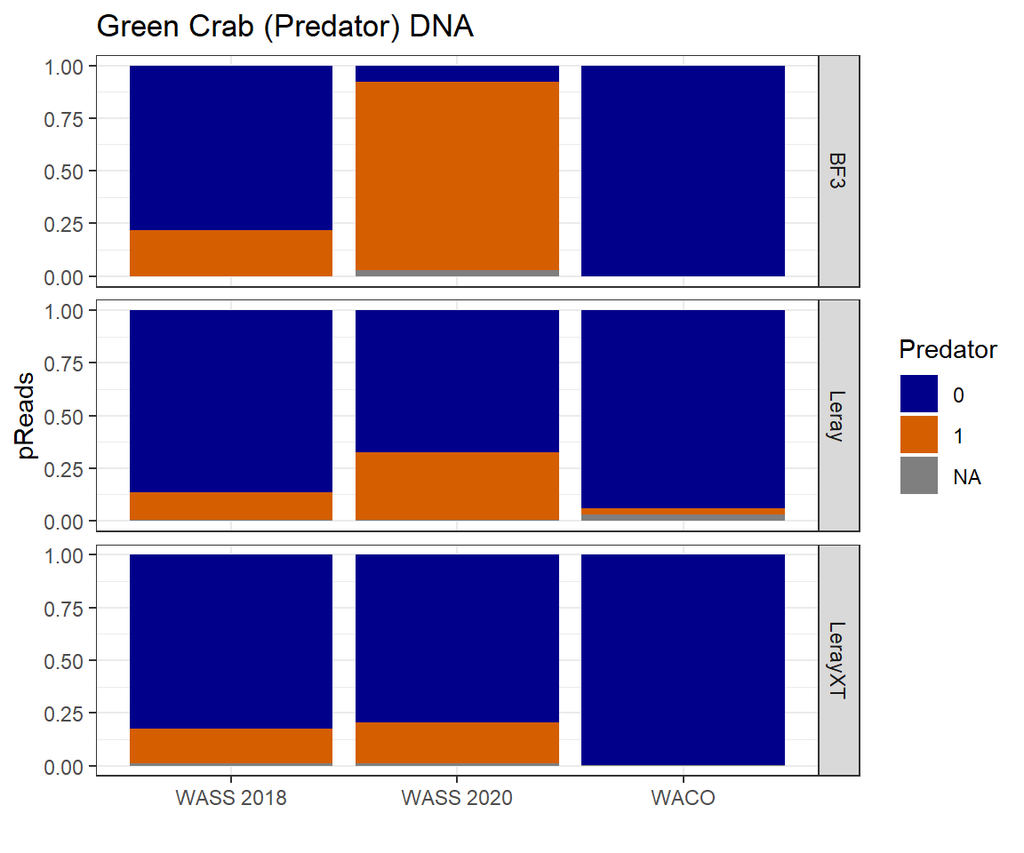

## Specificity

Can we resolve a similar proportion of ASVs down to lower taxonomic levels in the WASS 2018 samples? **Yes - although fewer ASVs for arthropods / annelids / molluscs**

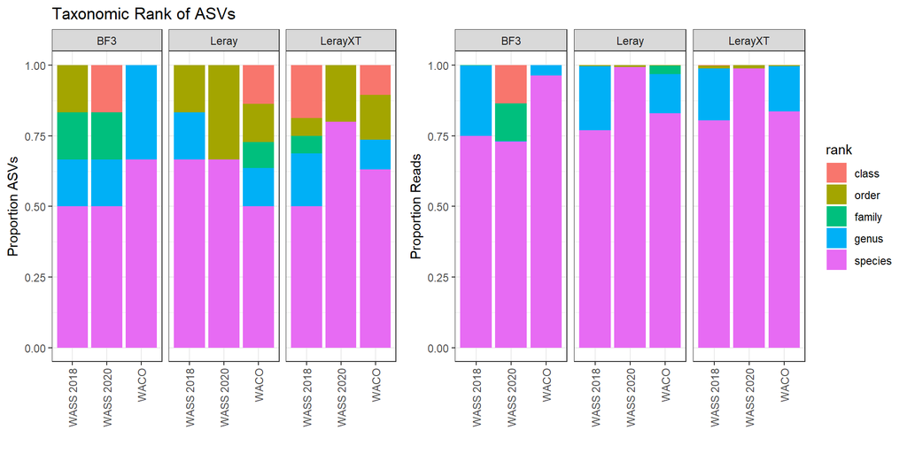

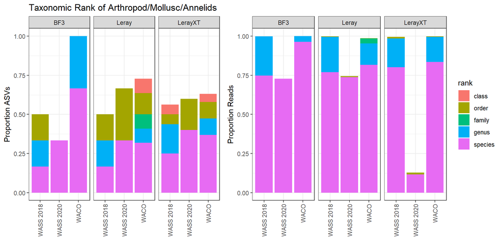

## Species of interest

**Are there any particular species that show up in the WASS 2020 samples that don’t show up in the WASS 2018 samples?**

```
## # A tibble: 7 x 4
##   phylum      taxon                    rank    sites
##   <chr>       <chr>                    <chr>   <chr>
## 1 Arthropoda  Cyprideis torosa         species WASS 2020
## 2 Arthropoda  Euglossa igniventris     species WASS 2020
## 3 Chlorophyta Chlorellaceae            family  WASS 2020
## 4 Rhodophyta  uncultured Bangiophyceae species WASS 2020
## 5 <NA>        Dinobryon                genus   WASS 2020
## 6 <NA>        Dinobryon divergens      species WASS 2020
## 7 <NA>        Hematodinium sp.         species WASS 2020
```

So primarily a bee, *Euglossia*, and an ostracod (*Cyprideis*). But WASS 2018 taxonomic output does have a bee genus, and some other insect taxonomic hits.